# jcee_analysis

Shealy and Katz

7/21/2020

Drop NAs for specific questions and filter out disciplines with fewer than 30 (the cutoff) students in sample

| Q29 | n |
| --- | --- |
| 13 | 631 |
| 5 | 571 |
| 4 | 473 |
| 8 | 275 |
| 3 | 128 |
| 16 | 127 |
| 11 | 109 |
| 10 | 95 |
| 7 | 91 |
| 17 | 91 |

[output cut: 8 more lines]

| Q29 | n |
| --- | --- |
| 13 | 631 |
| 5 | 571 |
| 4 | 473 |
| 8 | 275 |
| 3 | 128 |
| 16 | 127 |
| 11 | 109 |
| 10 | 95 |
| 7 | 91 |
| 17 | 91 |

[output cut: 4 more lines]

Major counts and percentages

| Q29 | major | n | pct_total | cumulat_pct |
| --- | --- | --- | --- | --- |
| 13 | Mec | 631 | 22.53 | 22.53 |
| 5 | Che | 571 | 20.39 | 42.91 |
| 4 | Civ | 473 | 16.89 | 59.80 |
| 8 | Ele | 275 | 9.82 | 69.62 |
| 3 | Bio | 128 | 4.57 | 74.19 |
| 16 | Softw | 127 | 4.53 | 78.72 |
| 11 | Ind | 109 | 3.89 | 82.61 |
| 10 | Env/Eco | 95 | 3.39 | 86.00 |
| 7 | Comp | 91 | 3.25 | 89.25 |
| 17 | Str/Arc | 91 | 3.25 | 92.50 |
| 1 | Aer/Oce | 70 | 2.50 | 95.00 |
| 12 | Mat | 53 | 1.89 | 96.89 |
| 18 | Gen | 53 | 1.89 | 98.79 |
| 6 | Con | 34 | 1.21 | 100.00 |

Gender counts overall

| Q37 | n | pct_total |
| --- | --- | --- |
| 1 | 2039 | 72.80 |
| 2 | 699 | 24.96 |
| 3 | 17 | 0.61 |
| 4 | 21 | 0.75 |
| NA | 25 | 0.89 |

Gender counts by major

| Q29 | major | Q37 | gender_in_major |
| --- | --- | --- | --- |
| 1 | Aer/Oce | 1 | 59 |
| 1 | Aer/Oce | 2 | 9 |
| 1 | Aer/Oce | 3 | 1 |
| 1 | Aer/Oce | NA | 1 |
| 3 | Bio | 1 | 70 |
| 3 | Bio | 2 | 56 |
| 3 | Bio | 3 | 1 |
| 3 | Bio | NA | 1 |
| 4 | Civ | 1 | 341 |
| 4 | Civ | 2 | 122 |
| 4 | Civ | 3 | 3 |
| 4 | Civ | 4 | 1 |
| 4 | Civ | NA | 6 |
| 5 | Che | 1 | 357 |
| 5 | Che | 2 | 207 |
| 5 | Che | 3 | 1 |
| 5 | Che | 4 | 5 |
| 5 | Che | NA | 1 |
| 6 | Con | 1 | 30 |
| 6 | Con | 2 | 4 |
| 7 | Comp | 1 | 80 |
| 7 | Comp | 2 | 8 |
| 7 | Comp | 3 | 2 |
| 7 | Comp | 4 | 1 |
| 8 | Ele | 1 | 221 |
| 8 | Ele | 2 | 44 |
| 8 | Ele | 3 | 3 |
| 8 | Ele | 4 | 3 |
| 8 | Ele | NA | 4 |
| 10 | Env/Eco | 1 | 40 |
| 10 | Env/Eco | 2 | 51 |
| 10 | Env/Eco | 3 | 2 |
| 10 | Env/Eco | 4 | 2 |
| 11 | Ind | 1 | 64 |
| 11 | Ind | 2 | 44 |
| 11 | Ind | NA | 1 |
| 12 | Mat | 1 | 38 |
| 12 | Mat | 2 | 14 |
| 12 | Mat | NA | 1 |
| 13 | Mec | 1 | 523 |
| 13 | Mec | 2 | 91 |
| 13 | Mec | 3 | 3 |
| 13 | Mec | 4 | 7 |
| 13 | Mec | NA | 7 |
| 16 | Softw | 1 | 107 |
| 16 | Softw | 2 | 18 |
| 16 | Softw | 4 | 1 |
| 16 | Softw | NA | 1 |
| 17 | Str/Arc | 1 | 73 |
| 17 | Str/Arc | 2 | 18 |
| 18 | Gen | 1 | 36 |
| 18 | Gen | 2 | 13 |
| 18 | Gen | 3 | 1 |
| 18 | Gen | 4 | 1 |
| 18 | Gen | NA | 2 |

### Distribution of technical vs social for civil engineering students

Summary statistics for Q28 factor

| item | mean | sd | n |
| --- | --- | --- | --- |
| Q28_social | 10.18 | 5.26 | 473 |
| Q28_social_norm | 2.04 | 1.05 | 473 |
| Q28_tech | 19.51 | 5.14 | 473 |
| Q28_tech_norm | 3.25 | 0.86 | 473 |

| Q29 | n |
| --- | --- |
| 1 | 70 |
| 3 | 128 |
| 4 | 473 |
| 5 | 571 |
| 6 | 34 |
| 7 | 91 |
| 8 | 275 |
| 10 | 95 |
| 11 | 109 |
| 12 | 53 |

[output cut: 4 more lines]

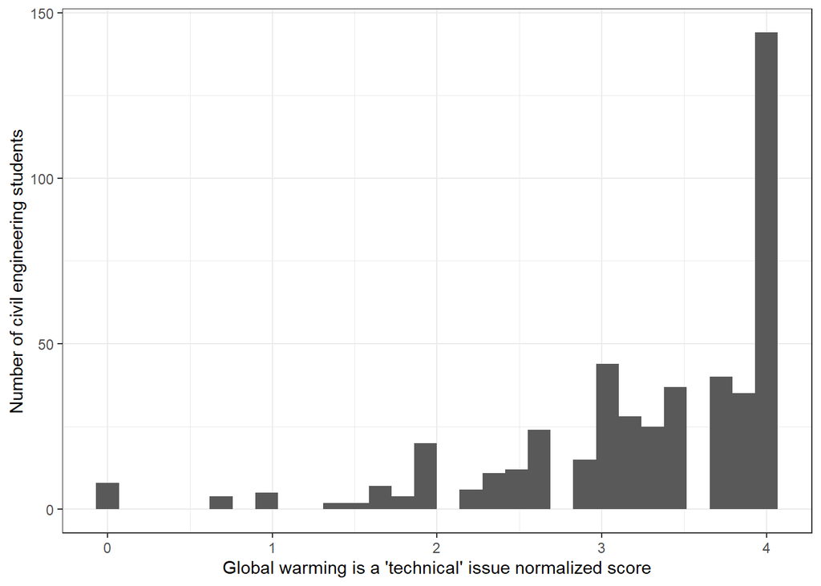

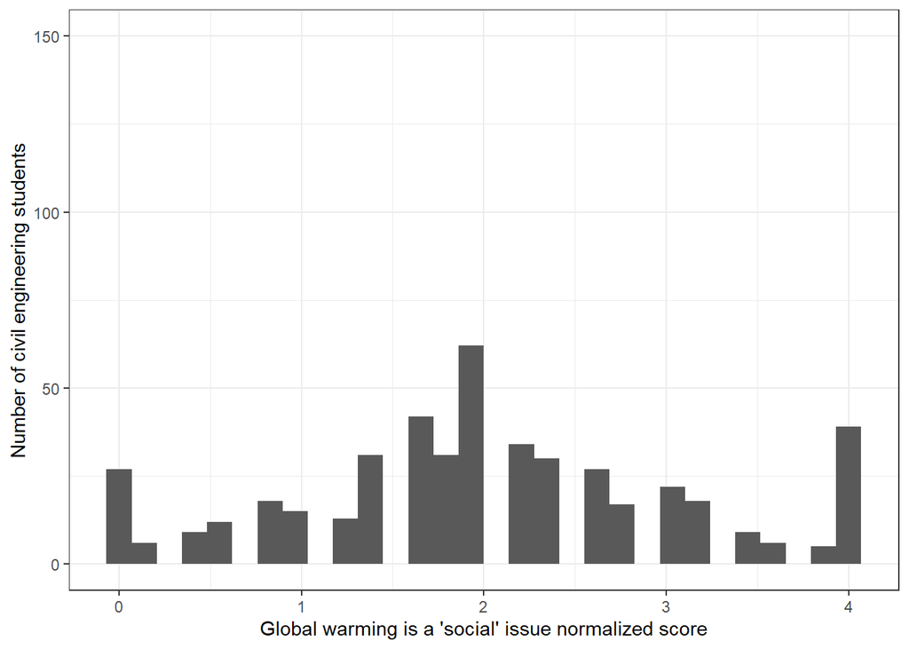

# RQ 1 - What do civil engineering students believe about global warming? (Q29d, Q18k, Q20a, Q20b, Q20d)

## Q18k - We should be taking stronger actions to address climate change

```
##
##        0   1
##   1   17  53
##   3   34  94
##   4  120 353
##   5  160 411
##   6   14  20
##   7   18  73
##   8   96 179
##   10   6  89
##   11  34  75
##   12  10  43
##   13 190 441
##   16  33  94
##   17  27  64
##   18  14  39
```

```
##
##  Pearson's Chi-squared test
##
## data:  cont_table_Q18k
## X-squared = 41.61, df = 13, p-value = 7.583e-05
```

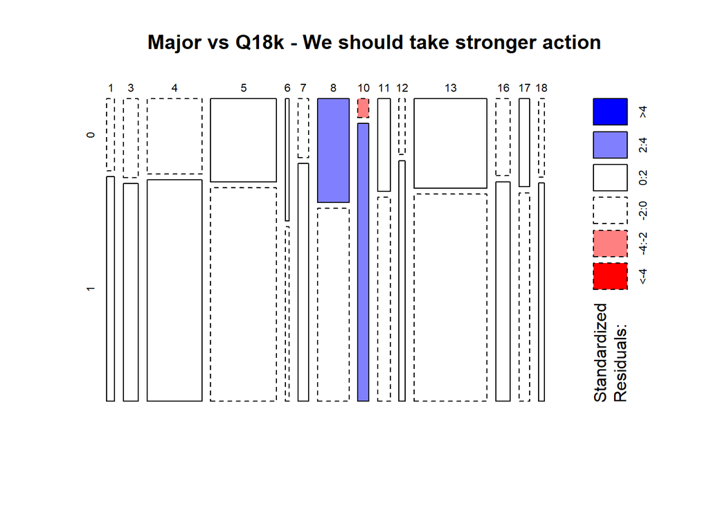

```
##
##            0    1
##   civil  120  353
##   other  653 1675
```

```
##
##  Pearson's Chi-squared test with Yates' continuity correction
##
## data:  cont_table_Q18k
## X-squared = 1.282, df = 1, p-value = 0.2575
```

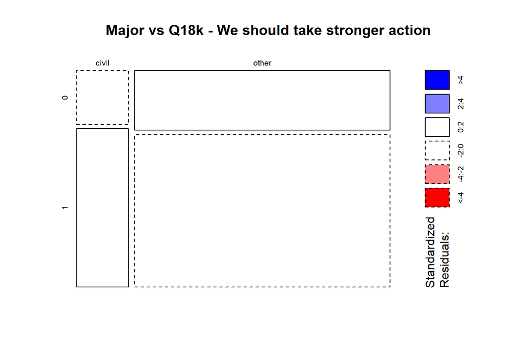

## Plot for Major by Q20a

```
##
##        0   1
##   1    8  62
##   3   20 108
##   4   74 399
##   5   95 476
##   6   10  24
##   7   18  73
##   8   68 207
##   10   8  87
##   11  20  89
##   12   7  46
##   13 139 492
##   16  21 106
##   17  17  74
##   18   9  44
```

```
##
##  Pearson's Chi-squared test
##
## data:  cont_table_Q20a
## X-squared = 29.903, df = 13, p-value = 0.004864
```

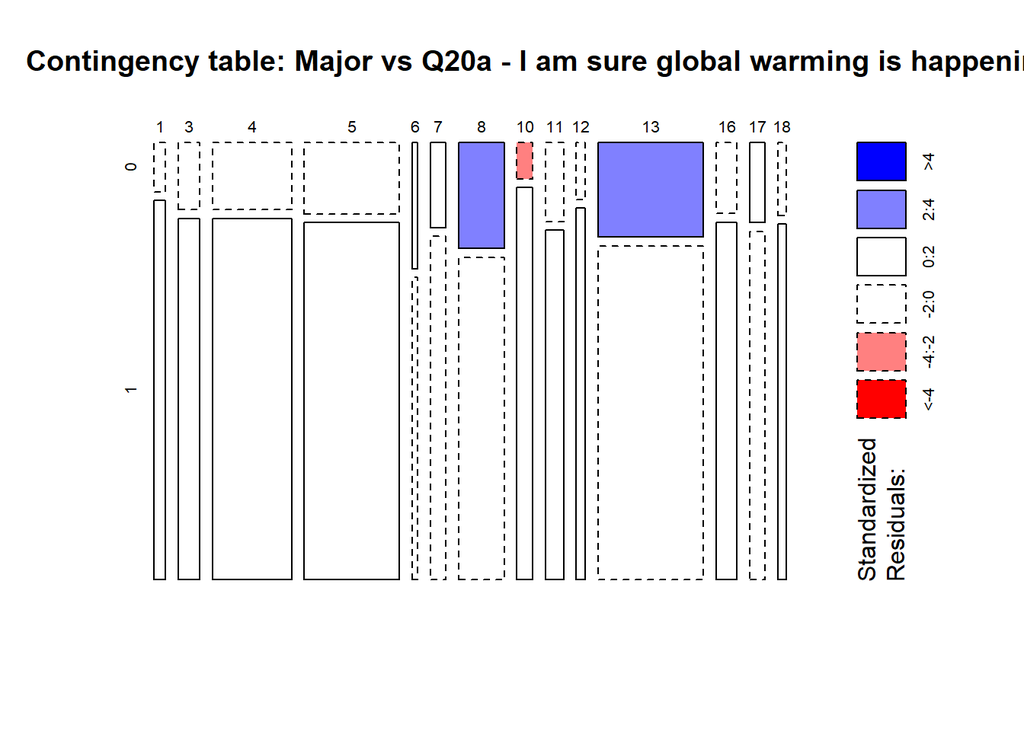

```
##
##            0    1
##   civil   74  399
##   other  440 1888
```

```
##
##  Pearson's Chi-squared test with Yates' continuity correction
##
## data:  cont_table_Q20a
## X-squared = 2.5678, df = 1, p-value = 0.1091
```

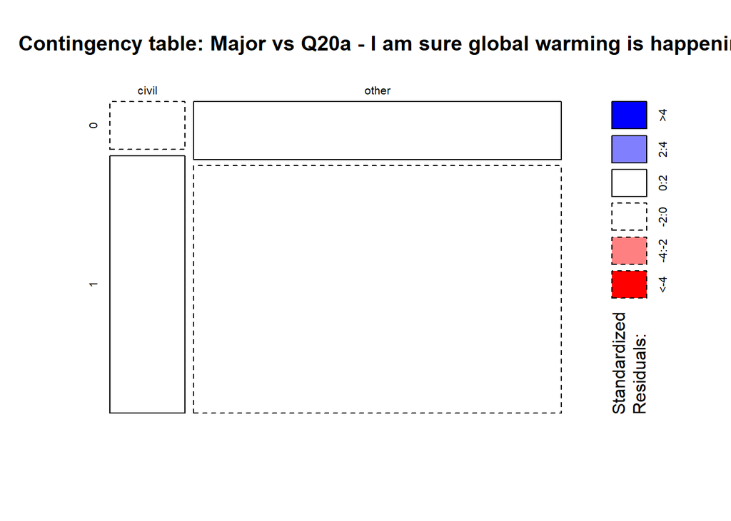

## Plot for Major by Q20b

```
##
##        0   1
##   1   19  51
##   3   29  99
##   4  123 350
##   5  152 419
##   6   15  19
##   7   22  69
##   8   83 192
##   10  12  83
##   11  32  77
##   12  13  40
##   13 211 420
##   16  32  95
##   17  27  64
##   18  18  35
```

```
##
##  Pearson's Chi-squared test
##
## data:  cont_table_Q20b
## X-squared = 31.25, df = 13, p-value = 0.0031
```

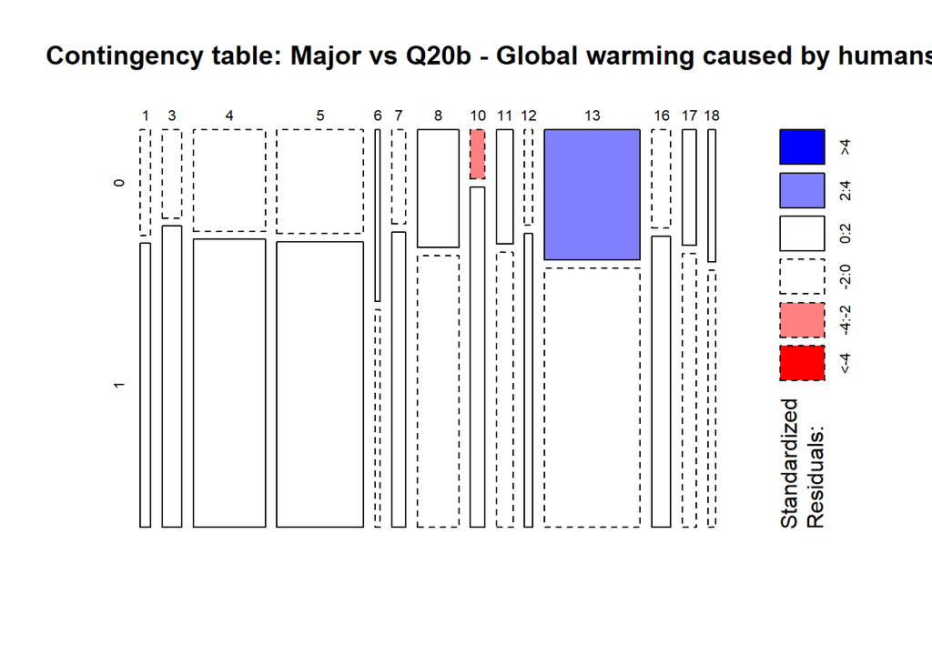

```
##
##            0    1
##   civil  123  350
##   other  665 1663
```

```
##
##  Pearson's Chi-squared test with Yates' continuity correction
##
## data:  cont_table_Q20b
## X-squared = 1.1518, df = 1, p-value = 0.2832
```

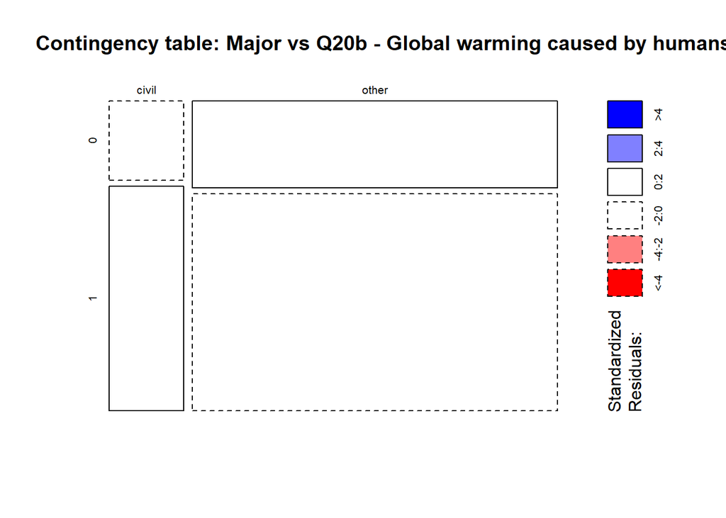

## Plot for Major by Q20d

```
##
##        0   1
##   1   34  36
##   3   69  59
##   4  208 265
##   5  255 316
##   6   21  13
##   7   38  53
##   8  140 135
##   10  14  81
##   11  54  55
##   12  17  36
##   13 340 291
##   16  67  60
##   17  46  45
##   18  24  29
```

```
##
##  Pearson's Chi-squared test
##
## data:  cont_table_Q20d
## X-squared = 69.894, df = 13, p-value = 8.395e-10
```

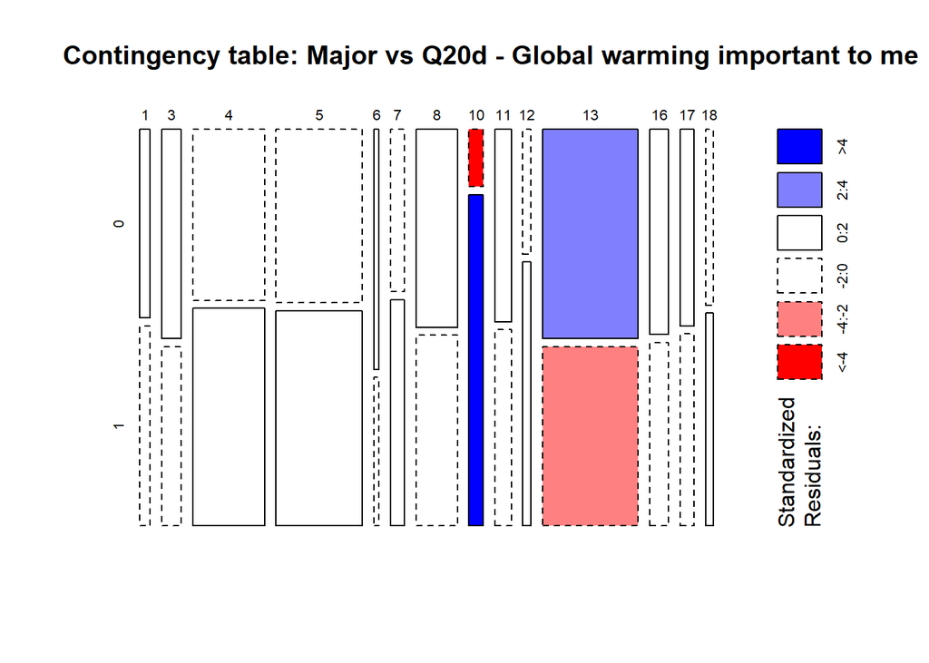

```
##
##            0    1
##   civil  208  265
##   other 1119 1209
```

```
##
##  Pearson's Chi-squared test with Yates' continuity correction
##
## data:  cont_table_Q20d
## X-squared = 2.4792, df = 1, p-value = 0.1154
```

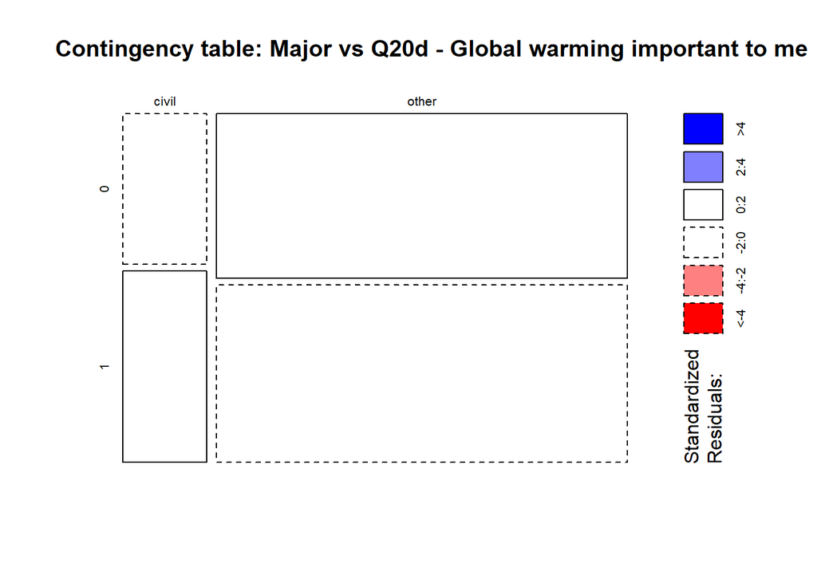

## Q22 - What percentage of climate scientists think that human-caused global warming is happening?

```
##
##        0   1
##   1   30  40
##   3   65  63
##   4  243 230
##   5  301 270
##   6   25   9
##   7   50  41
##   8  144 131
##   10  41  54
##   11  70  39
##   12  19  34
##   13 343 288
##   16  47  80
##   17  54  37
##   18  30  23
```

```
##
##  Pearson's Chi-squared test
##
## data:  cont_table_Q22
## X-squared = 39.519, df = 13, p-value = 0.0001652
```

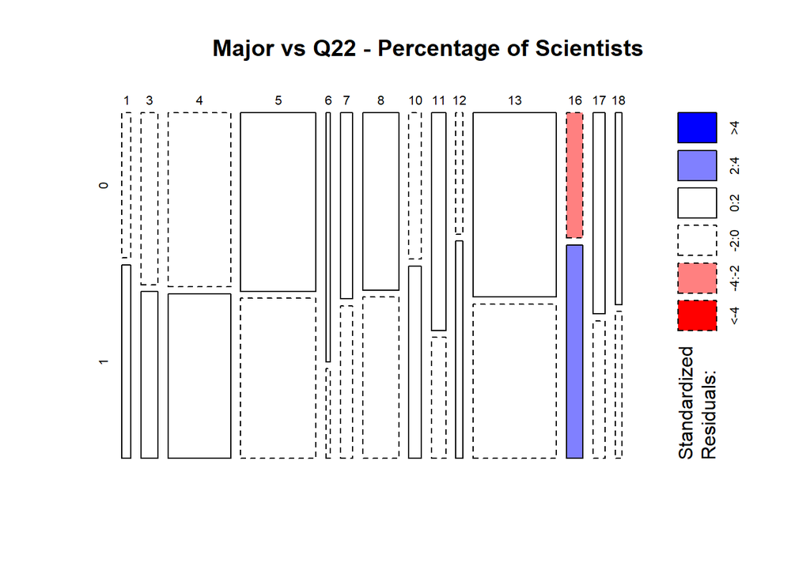

```
##
##            0    1
##   civil  243  230
##   other 1219 1109
```

```
##
##  Pearson's Chi-squared test with Yates' continuity correction
##
## data:  cont_table_Q22
## X-squared = 0.11684, df = 1, p-value = 0.7325
```

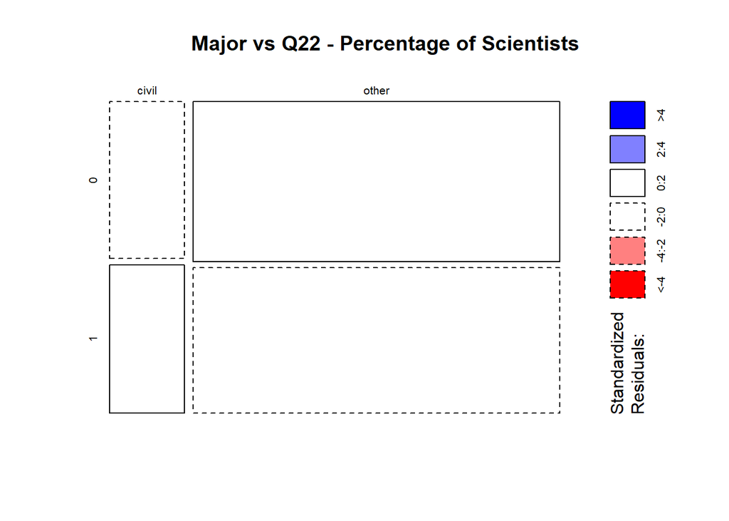

Set colors for majors for all plots

## Q23 - I believe that a cause of global climate change is…

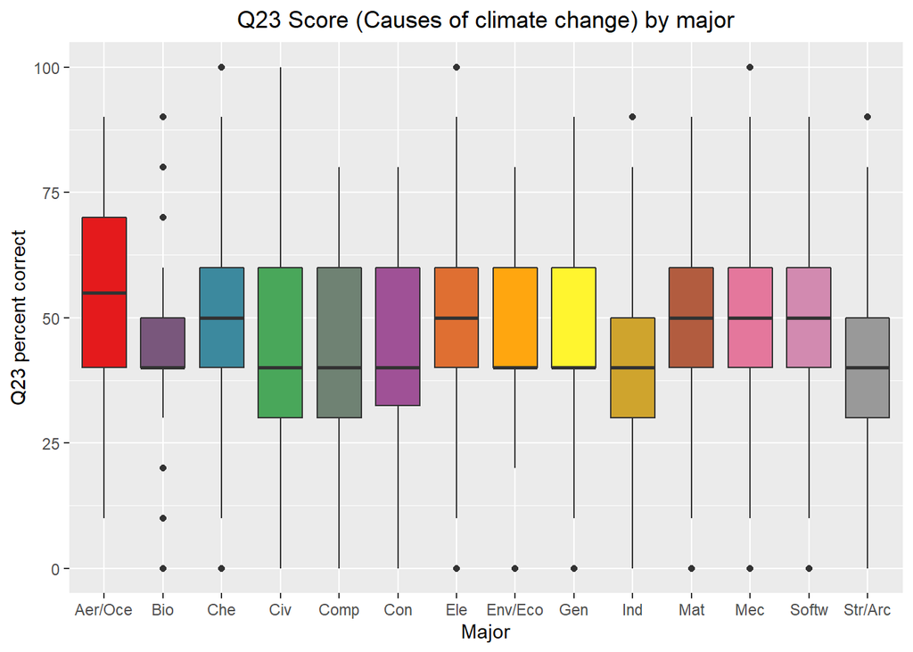

### ANOVA for Q23 scores by major

```
##               Df Sum Sq Mean Sq F value   Pr(>F)
## major         13    174  13.422   3.843 3.47e-06 ***
## Residuals   2787   9733   3.492
## ---
## Signif. codes:  0 '***' 0.001 '**' 0.01 '*' 0.05 '.' 0.1 ' ' 1
```

```
##   Tukey multiple comparisons of means
##     95% family-wise confidence level
##
## Fit: aov(formula = Q23_bin_total ~ major, data = climate_df)
##
## $major
##                        diff         lwr         upr     p adj
## Bio-Aer/Oce     -1.22500000 -2.15747402 -0.29252598 0.0008972
## Che-Aer/Oce     -0.89772329 -1.69208828 -0.10335831 0.0111836
## Civ-Aer/Oce     -1.18350951 -1.98681082 -0.38020820 0.0000707
## Comp-Aer/Oce    -1.33626374 -2.33350760 -0.33901987 0.0006035
## Con-Aer/Oce     -1.45294118 -2.76419371 -0.14168864 0.0146770
## Ele-Aer/Oce     -1.05454545 -1.89429994 -0.21479097 0.0020876
## Env/Eco-Aer/Oce -0.64210526 -1.63017887  0.34596835 0.6433739
## Gen-Aer/Oce     -0.99622642 -2.13837801  0.14592518 0.1663641
## Ind-Aer/Oce     -1.25137615 -2.21215270 -0.29059959 0.0010606
## Mat-Aer/Oce     -0.90188679 -2.04403839  0.24026481 0.3087560
## Mec-Aer/Oce     -0.93755943 -1.72778933 -0.14732953 0.0054135
## Softw-Aer/Oce   -0.65511811 -1.58888911  0.27865289 0.5138598
## Str/Arc-Aer/Oce -1.47912088 -2.47636474 -0.48187702 0.0000598
## Che-Bio          0.32727671 -0.28616556  0.94071898 0.8805742
## Civ-Bio          0.04149049 -0.58348046  0.66646144 1.0000000
## Comp-Bio        -0.11126374 -0.97137479  0.74884731 1.0000000
## Con-Bio         -0.22794118 -1.43818037  0.98229802 0.9999965
## Ele-Bio          0.17045455 -0.50072597  0.84163506 0.9998845
## Env/Eco-Bio      0.58289474 -0.26656695  1.43235642 0.5525759
## Gen-Bio          0.22877358 -0.79582681  1.25337398 0.9999736
## Ind-Bio         -0.02637615 -0.84392571  0.79117341 1.0000000
## Mat-Bio          0.32311321 -0.70148719  1.34771360 0.9987847
## Mec-Bio          0.28744057 -0.32063755  0.89551869 0.9497633
## Softw-Bio        0.56988189 -0.21575415  1.35551793 0.4548650
## Str/Arc-Bio     -0.25412088 -1.11423193  0.60599017 0.9993896
## Civ-Che         -0.28578622 -0.67578188  0.10420944 0.4368519
## Comp-Che        -0.43854044 -1.14656512  0.26948423 0.7159674
## Con-Che         -0.55521788 -1.66255110  0.55211533 0.9220845
## Ele-Che         -0.15682216 -0.61724720  0.30360287 0.9973303
## Env/Eco-Che      0.25561803 -0.43943095  0.95066701 0.9943368
## Gen-Che         -0.09850312 -0.99923277  0.80222652 1.0000000
## Ind-Che         -0.35365285 -1.00931680  0.30201109 0.8717336
## Mat-Che         -0.00416350 -0.90489315  0.89656615 1.0000000
```

[output cut: 43 more lines]

```
## Ind-Gen         -0.25514973 -1.30557334  0.79527388 0.9999303
## Mat-Gen          0.09433962 -1.12418754  1.31286678 1.0000000
## Mec-Gen          0.05866699 -0.83841800  0.95575197 1.0000000
## Softw-Gen        0.34110830 -0.68467259  1.36688920 0.9979034
## Str/Arc-Gen     -0.48289446 -1.56677337  0.60098445 0.9686493
## Mat-Ind          0.34948935 -0.70093425  1.39991296 0.9978920
## Mec-Ind          0.31381672 -0.33683126  0.96446469 0.9414346
## Softw-Ind        0.59625804 -0.22277052  1.41528659 0.4484525
## Str/Arc-Ind     -0.22774473 -1.11846063  0.66297116 0.9998754
## Mec-Mat         -0.03567264 -0.93275762  0.86141235 1.0000000
## Softw-Mat        0.24676868 -0.77901222  1.27254958 0.9999376
## Str/Arc-Mat     -0.57723409 -1.66111300  0.50664482 0.8819611
## Softw-Mec        0.28244132 -0.32762383  0.89250646 0.9572896
## Str/Arc-Mec     -0.54156145 -1.24494365  0.16182075 0.3508101
## Str/Arc-Softw   -0.82400277 -1.68551975  0.03751421 0.0777419
```

### T-test for Q23 scores by civl vs others

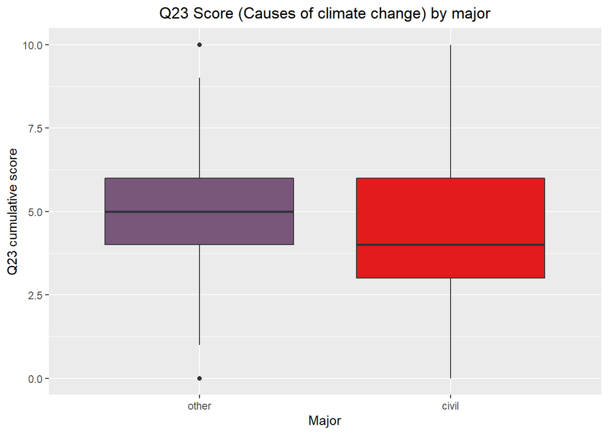

Checking t-test assumptions

```
##
##  Shapiro-Wilk normality test
##
## data:  Q23_bin_total[Q29_binned == "civil"]
## W = 0.96554, p-value = 4.314e-09
```

```
##
##  Shapiro-Wilk normality test
##
## data:  Q23_bin_total[Q29_binned == "other"]
## W = 0.96356, p-value < 2.2e-16
```

```
##
##  F test to compare two variances
##
## data:  Q23_bin_total by Q29_binned
## F = 0.98956, num df = 472, denom df = 2327, p-value = 0.8957
## alternative hypothesis: true ratio of variances is not equal to 1
## 95 percent confidence interval:
##  0.8630664 1.1420837
## sample estimates:
## ratio of variances
##          0.9895576
```

```
##
##  Welch Two Sample t-test
##
## data:  Q23_bin_total by Q29_binned
## t = -2.3527, df = 679.91, p-value = 0.01892
## alternative hypothesis: true difference in means is not equal to 0
## 95 percent confidence interval:
##  -0.40773733 -0.03677311
## sample estimates:
## mean in group civil mean in group other
##            4.416490            4.638746
```

## Q24 - I believe a way to help reduce or slow down climate change is…

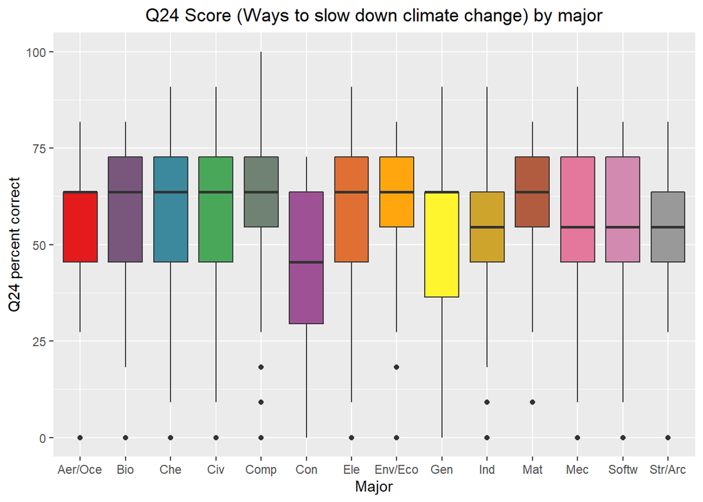

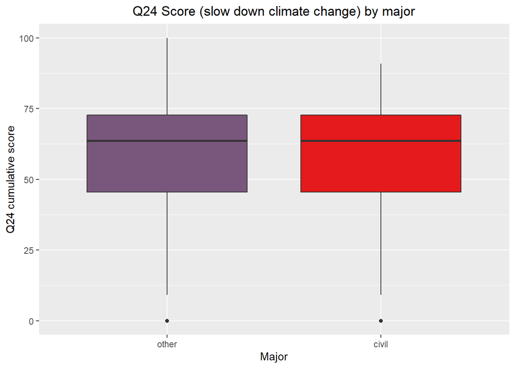

```
##
##  Welch Two Sample t-test
##
## data:  Q24_bin_total by Q29_binned
## t = 0.69219, df = 662.07, p-value = 0.4891
## alternative hypothesis: true difference in means is not equal to 0
## 95 percent confidence interval:
##  -0.1332923  0.2784322
## sample estimates:
## mean in group civil mean in group other
##            6.217759            6.145189
```

## Q25 Which of the following…

1. is the most abundant greenhouse gas
2. amplifies the greenhouse gas effect the most?
3. should we be most concerned about when thinking about global warming? CO2

### Q25a

```
##
##        0   1
##   1   57  13
##   3  113  15
##   4  427  46
##   5  490  81
##   6   29   5
##   7   85   6
##   8  245  30
##   10  68  27
##   11  94  15
##   12  43  10
##   13 543  88
##   16 117  10
##   17  77  14
##   18  47   6
```

```
##
##  Pearson's Chi-squared test
##
## data:  cont_table_Q25a
## X-squared = 37.265, df = 13, p-value = 0.0003764
```

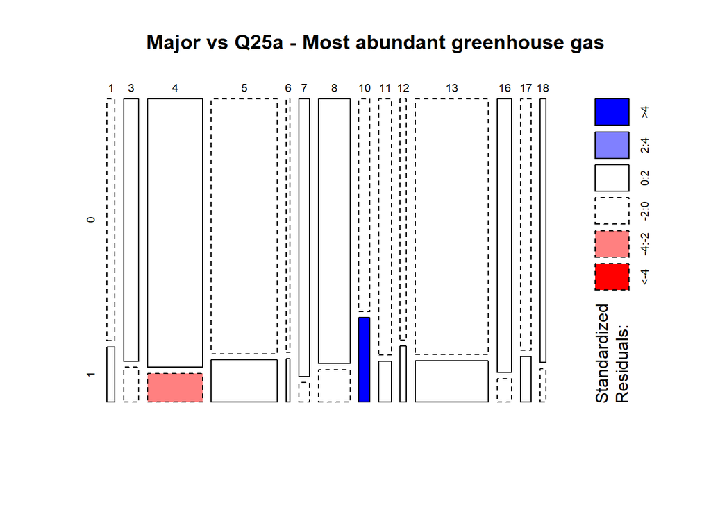

```
##
##            0    1
##   civil  427   46
##   other 2008  320
```

```
##
##  Pearson's Chi-squared test with Yates' continuity correction
##
## data:  cont_table_Q25a
## X-squared = 5.246, df = 1, p-value = 0.022
```

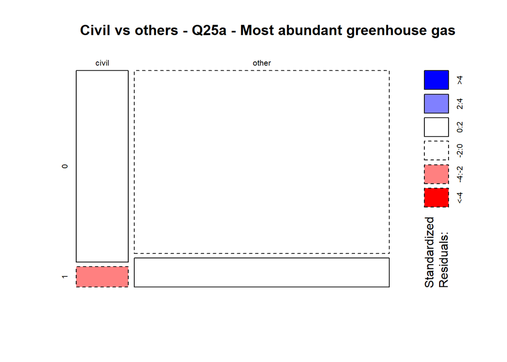

### Q25b

```
##
##        0   1
##   1   40  30
##   3   77  51
##   4  300 173
##   5  373 198
##   6   23  11
##   7   52  39
##   8  172 103
##   10  45  50
##   11  69  40
##   12  31  22
##   13 381 250
##   16  79  48
##   17  49  42
##   18  32  21
```

```
##
##  Pearson's Chi-squared test
##
## data:  cont_table_Q25b
## X-squared = 17.332, df = 13, p-value = 0.1846
```

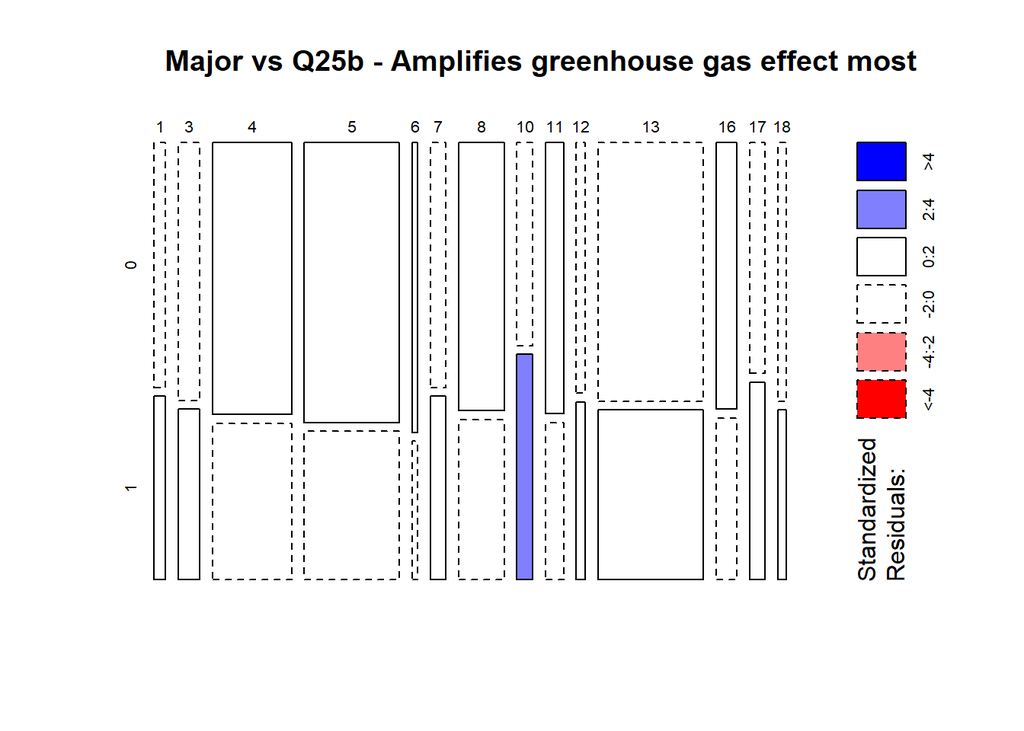

```
##
##            0    1
##   civil  300  173
##   other 1423  905
```

```
##
##  Pearson's Chi-squared test with Yates' continuity correction
##
## data:  cont_table_Q25b
## X-squared = 0.78362, df = 1, p-value = 0.376
```

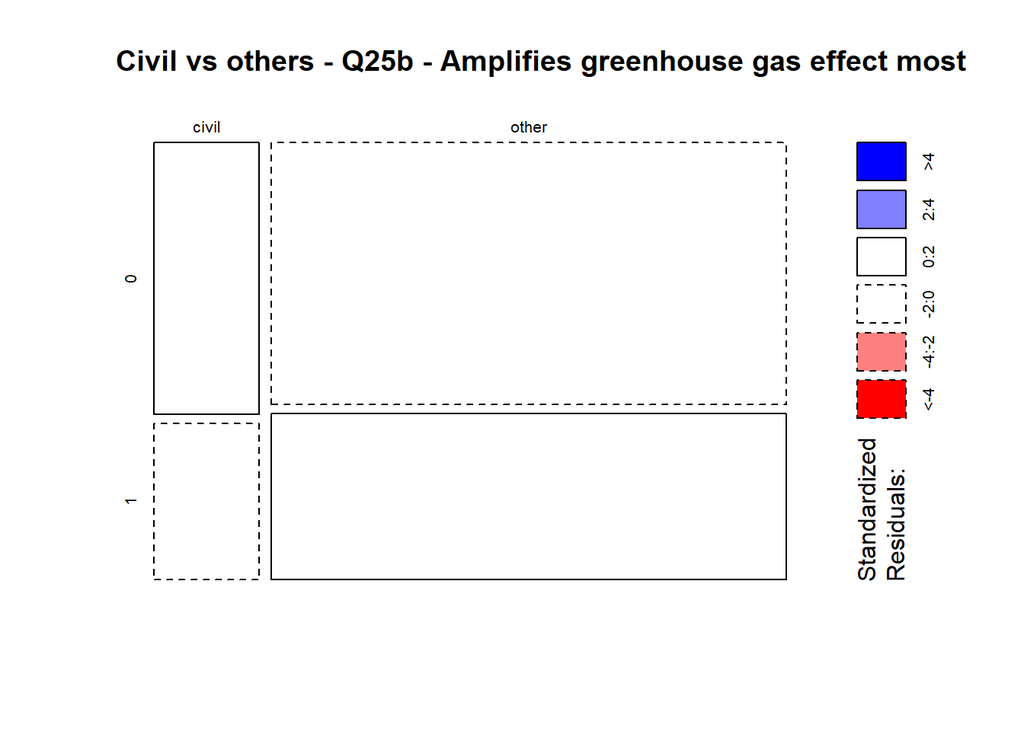

Q25c

```
##
##        0   1
##   1   32  38
##   3   63  65
##   4  219 254
##   5  237 334
##   6   17  17
##   7   43  48
##   8  117 158
##   10  42  53
##   11  67  42
##   12  17  36
##   13 258 373
##   16  62  65
##   17  44  47
##   18  22  31
```

```
##
##  Pearson's Chi-squared test
##
## data:  cont_table_Q25c
## X-squared = 26.031, df = 13, p-value = 0.01684
```

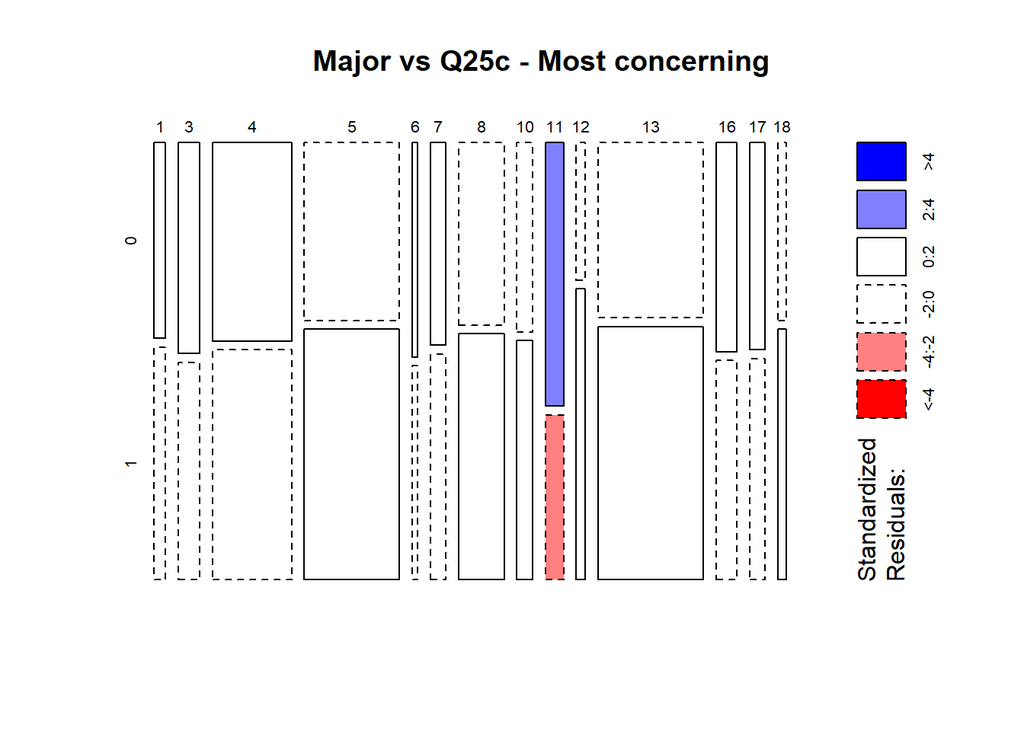

```
##
##            0    1
##   civil  219  254
##   other 1021 1307
```

```
##
##  Pearson's Chi-squared test with Yates' continuity correction
##
## data:  cont_table_Q25c
## X-squared = 0.85442, df = 1, p-value = 0.3553
```

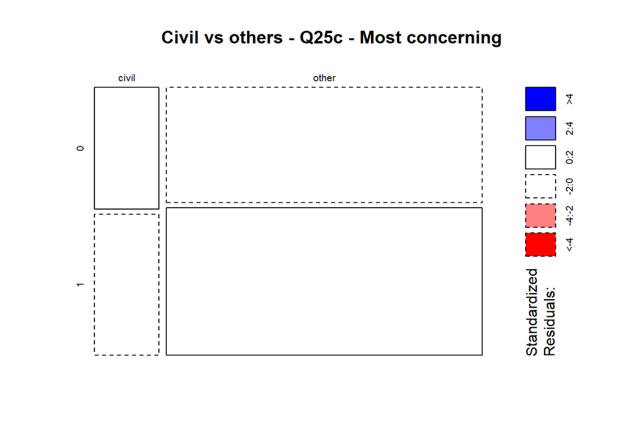

## Q26 - How much do you agree or disagree with the following statements about Earth’s climate?

Recoding Q26 for t/F and then creating a total score out of 8

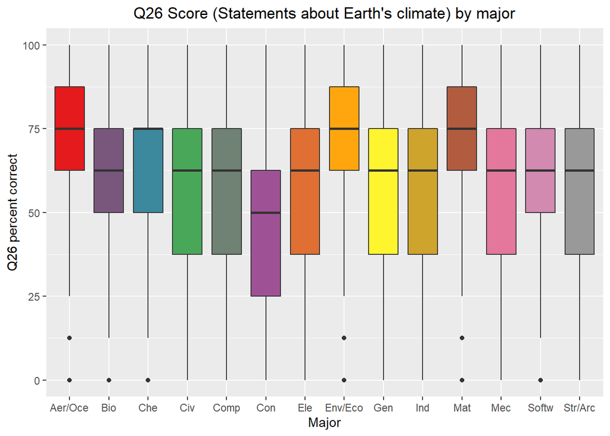

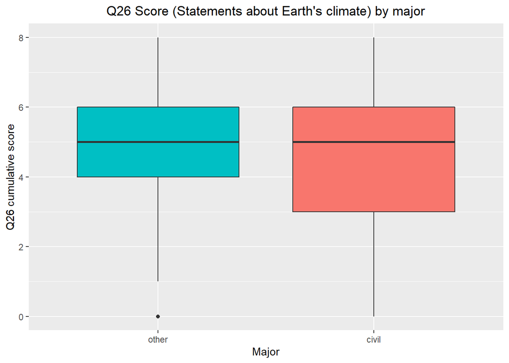

```
##
##  Welch Two Sample t-test
##
## data:  Q26_bin_total by Q29_binned
## t = -1.9156, df = 687.39, p-value = 0.05583
## alternative hypothesis: true difference in means is not equal to 0
## 95 percent confidence interval:
##  -0.412792136  0.005092507
## sample estimates:
## mean in group civil mean in group other
##            4.663848            4.867698
```

### Q26 EFA

| Q26a | Q26a_rev | Q26b | Q26b_rev | Q26d |
| --- | --- | --- | --- | --- |
| 3 | 1 | 2 | 2 | 2 |
| 0 | 4 | 0 | 4 | 0 |
| 1 | 3 | 0 | 4 | 2 |
| 1 | 3 | 0 | 4 | 4 |
| 0 | 4 | 0 | 4 | 2 |
| 0 | 4 | 1 | 3 | 3 |
| 0 | 4 | 0 | 4 | 3 |
| 0 | 4 | 3 | 1 | 1 |
| 0 | 4 | 1 | 3 | 2 |
| 0 | 4 | 0 | 4 | 3 |

[output cut: 2791 more lines]

```
## Factor Analysis using method =  minres
## Call: fa(r = q26_cor, nfactors = 2)
## Standardized loadings (pattern matrix) based upon correlation matrix
##            MR1   MR2   h2   u2 com
## Q26a_rev  0.54 -0.07 0.28 0.72 1.0
## Q26b_rev  0.73  0.19 0.61 0.39 1.1
## Q26c_rev  0.46 -0.34 0.28 0.72 1.8
## Q26d     -0.05  0.53 0.28 0.72 1.0
## Q26e     -0.34  0.45 0.27 0.73 1.8
## Q26f      0.21  0.70 0.58 0.42 1.2
## Q26g_rev  0.65 -0.20 0.42 0.58 1.2
## Q26h_rev  0.74  0.14 0.59 0.41 1.1
##
##                        MR1  MR2
## SS loadings           2.14 1.17
## Proportion Var        0.27 0.15
## Cumulative Var        0.27 0.41
## Proportion Explained  0.65 0.35
## Cumulative Proportion 0.65 1.00
##
##  With factor correlations of
##      MR1  MR2
## MR1 1.00 0.15
## MR2 0.15 1.00
##
## Mean item complexity =  1.3
## Test of the hypothesis that 2 factors are sufficient.
##
## The degrees of freedom for the null model are  28  and the objective function was  1.77
## The degrees of freedom for the model are 13  and the objective function was  0.06
##
## The root mean square of the residuals (RMSR) is  0.03
## The df corrected root mean square of the residuals is  0.04
##
## Fit based upon off diagonal values = 0.99
## Measures of factor score adequacy
##                                                    MR1  MR2
## Correlation of (regression) scores with factors   0.90 0.83
## Multiple R square of scores with factors          0.81 0.69
## Minimum correlation of possible factor scores     0.63 0.38
```

#### There appear to be two factors from Q26 - one for low information (items a, b, c, g, and h) and one for higher information (d, e, f)

Create two new factors for Q26 (Q26_low_info, from the reverse-coded a,b,c,g,h and Q26_high_info from d,e,f)

#### Compare scores for low info among different majors

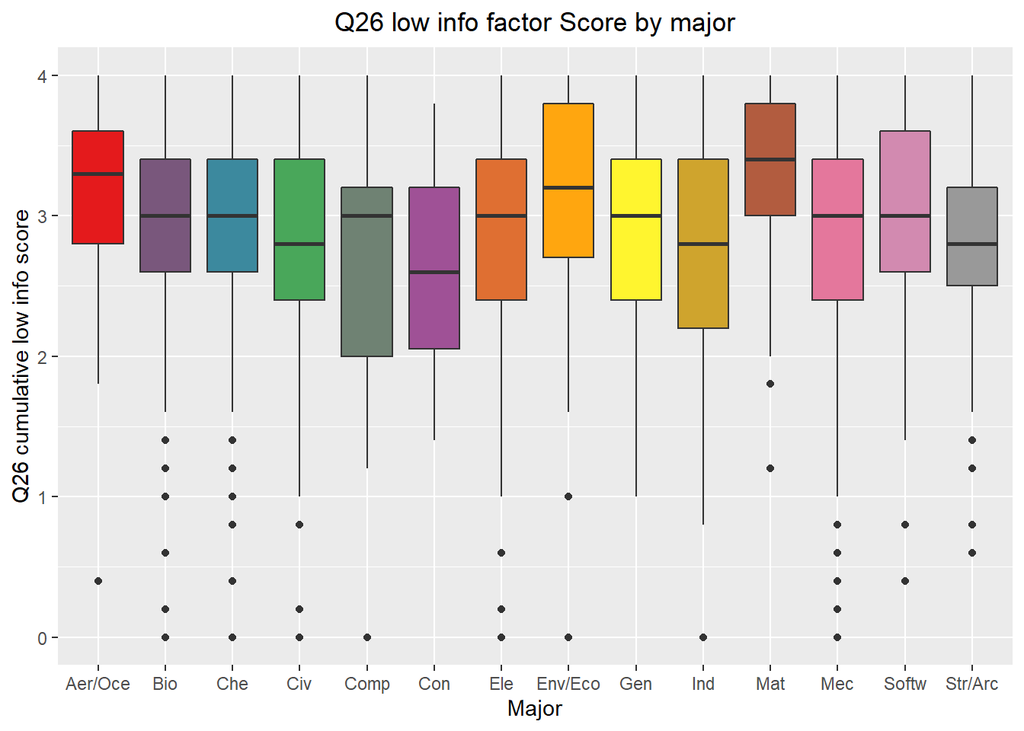

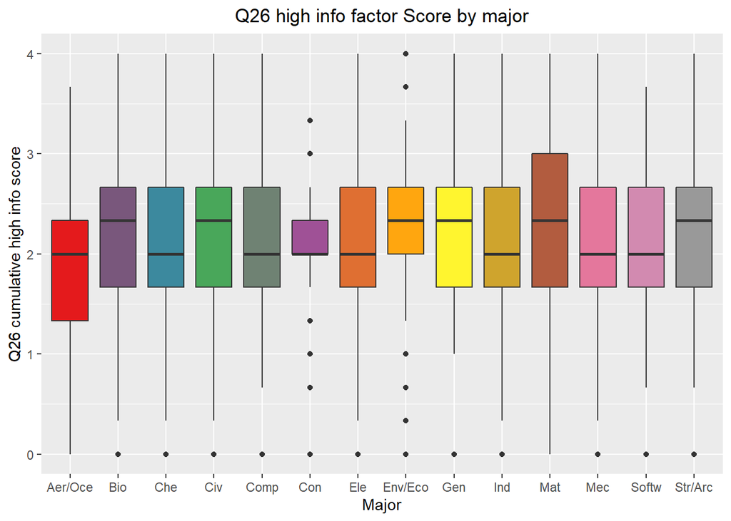